# LUAD vs LUSC

Jaeho Jeong

# LUAD vs LUSC

## Lung Cancer

- **폐암(Lung Cancer)**이란 폐에 비정상적인 암세포가 무절제하게 증식하여 종괴(덩어리)를 형성하고 인체에 해를 미치는 것을 말합니다.
- **폐암(Lung Cancer)**은 진행되면 반대쪽 폐뿐만 아니라 임파선이나 혈액을 통하여 뼈, 간, 부신, 신장, 뇌, 척수 등 온몸으로 전이될 수 있어 약 86%의 사망률을 가진 위험한 병입니다.

### 비소세포폐암(non-samll-cell lung cancer)

- 폐암은 암세포의 크기와 형태 등 병리조직학적 기준에 따라 소세포폐암과 비소세포폐암으로 나뉜다.
- 현미경으로 확인되는 암세포의 크기가 작은 것을 소세포폐암이라 하고, 작지 않은 것을 비소세포폐암이라고 한다.
- 비소세포폐암은 발생하는 폐암의 80~85%를 차지하고, 크게 `선암(LUAD)`과 `편평상피세포암(LUSC)`로 나눌 수 있다.

### Representative 2 Types

- `선암(LUAD)`  
  특정 물질의 분비를 주된 기능으로 하는 인체의 선세포에 생기는 암을 뜻한다.  
  폐암 종류 가운데서 발생 빈도가 가장 높다.
- `편평상피세포암(LUSC)`  
  폐의 기관지 점막을 구성하는 편평상피세포가 변성해서 생기는 암을 뜻한다.  
  주로 폐 중심부에서 발견되며, 남자에게 흔하고 흡연과 관련이 많습니다.

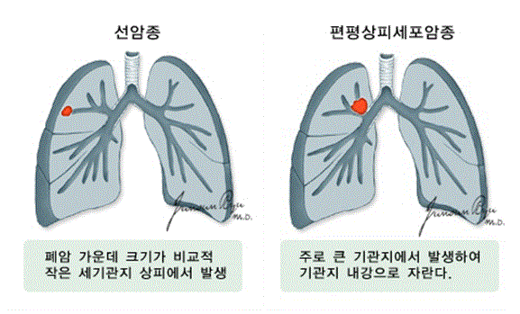

## Thesis

[Distinct lung cancer subtypes associate to distinct drivers of tumor progression](https://www.ncbi.nlm.nih.gov/pmc/articles/PMC6238974/)

### Abstract

우리는 발견된 암 관련 요인들의 예후의 영향을 조사하기 위하여 이 분야에 대해 탐구합니다.

이 연구는 LUAD 또는 LUSC의 임상의 결과에 영향을 미치는 69가지의 구분된 예후의 암 요인들을 발견하기 위함이다.  
이는 암 성장, 세포 순환, 전사 인자 그리고 신진대사의 핵심 요인이다.  
LUAD와 LUSC간에 가끔 완전히 다른 요인들이 존재하고 종종 임상 결과에서 반대의 영향을 미치기도 한다.  
따라서, NSCLC의 부분집합에 관해 차이가 나는 사항 역시 고려되어야 한다.

### Introduction

폐암은 크게 소세포폐암(SCLC)과 비소세포폐암(NSCLC)으로 나뉜다.  
NSCLC와 SCLC를 구분하는것은 명확하지만 NSCLC에 속하는 폐암 종류들을 구분하는것은 아직 명확하지 않는다.

서로 구분된 유전자 집합들은 LUAD와 LUSC에서 차이가 존재한다.  
`Charkiewicz et al`의 연구에서는 LUAD와 LUSC사이의 진단으로 53개의 유전자 특징이 발견되엇다.  
그리고 추가적인 유전 집단들 역시 `Liu et al`에 의하여 발견되었다.

- **LUAD**과 관련된 유전자들은 단단한 연결지점과 세포 부착 구성요소들이 포함되어있다.

이 분석은 **transcriptomic DNA microarray**와 **clinical data**를 이용하여 실시된다.

### Result

이 논문에서는 LUAD와 LUSC간 다르게 표현되는 유전자들에 관하여 탐구해보았습니다.  
주로 `survival analysis`와 `forest plot`을 통해 비교를 실시하였다.

**Survival Analysis**

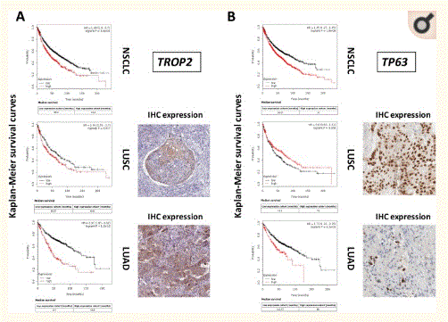

[Result of survival analysis](https://www.ncbi.nlm.nih.gov/core/lw/2.0/html/tileshop_pmc/tileshop_pmc_inline.html?title=Click%20on%20image%20to%20zoom&p=PMC3&id=6238974_oncotarget-09-35528-g001.jpg)

**Forest Plots**

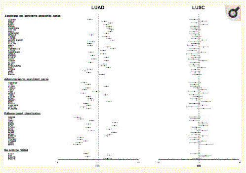

[Forest plots](https://www.ncbi.nlm.nih.gov/core/lw/2.0/html/tileshop_pmc/tileshop_pmc_inline.html?title=Click%20on%20image%20to%20zoom&p=PMC3&id=6238974_oncotarget-09-35528-g004.jpg)

**Forest Plot**은 LUAD vs LUSC에서 나타난 반대의 영향과 overexpress된 각각의 요인들의 영향을 요약해준다.  
LUAD와 LUSC 각각에서 가운데 점선은 `HR=1`을 뜻한다.  
* risk value들의 중앙값은 점들로 표현된다. * 신뢰구간은 수평선들로 표현된다.

**Network Analysis**

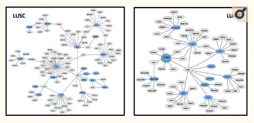

[Network analysis](https://www.ncbi.nlm.nih.gov/core/lw/2.0/html/tileshop_pmc/tileshop_pmc_inline.html?title=Click%20on%20image%20to%20zoom&p=PMC3&id=6238974_oncotarget-09-35528-g006.jpg)

**Control Network**는 LUAD와 LUSC에서 완전히 다른 세포 성장과 세포자멸사를 확인하기 위하여 사용  
* 유전자들은 노드로써 나타난다. * 노드들간의 생물학적인 관계들은 선들로 나타난다. * LUSC(left panel)과 LUAD(right panel)에서 overexpress된 유전자들은 파란색으로 표현되었고, direct interactor는 회색으로 표현되었다.

### Materials and Methods

**Materials**

- the pre-processed summarized experiment datasets
  - ./LUAD/all/LUAD_Illumina_HiSeq_all.rda
  - ./LUAD/paired/LUAD_Illumina_HiSeq_paired.rda
  - ./LUSC/all/LUSC_Illumina_HiSeq_all.rda
  - ./LUSC/paired/LUSC_Illumina_HiSeq_paired.rda
- the summarized experiment datasets upon filtering of tumor purity
  - ./LUAD/all/LUAD_Illumina_HiSeq_all_tumorPurity.rda
  - ./LUAD/paired/LUAD_Illumina_HiSeq_paired_tumorPurity.rda
  - ./LUAD/unpaired/LUAD_Illumina_HiSeq_unpaired_tumorPurity.rda
  - ./LUSC/all/LUSC_Illumina_HiSeq_all_tumorPurity.rda
  - ./LUSC/paired/LUAD_Illumina_HiSeq_paired_tumorPurity.rda
  - ./LUSC/unpaired/LUSC_Illumina_HiSeq_unpaired_tumorPurity.rda
- the summarized experiment datasets upon the normalization steps
  - ./LUAD/all/LUAD_PreprocessedData_all_tumorPurity.rda
  - ./LUAD/paired/LUAD_PreprocessedData_paired_tumorPurity.rda
  - ./LUAD/unpaired/LUAD_PreprocessedData_unpaired_tumorPurity.rda
  - ./LUSC/all/LUSC_PreprocessedData_all_tumorPurity.rda
  - ./LUSC/paired/LUSC_PreprocessedData_paired_tumorPurity.rda
  - ./LUSC/unpaired/LUSC_PreprocessedData_unpaired_tumorPurity.rda

**Methods**

위의 데이터들을 활용하여  
**Survival Analysis**  
**Network Analysis**  
위의 두 가지 분석을 실시하여 LUSC와 LUAD간의 차이가 존재하는 유전자들을 식별하는 것을 목표로 삼았습니다.

# PRACTICE

## 1

## 2

## 3

## 4

## 5

## 6

## 7

## 8

## 9

## 10

## 11

## 12

## 13